# Session 2 · Lab 3: p-Hacking & False Discovery Rate

Understanding and Controlling the Multiplicity Problem

Author

Prof. Dr. Jörg Schoder

Published

today

## 1 Scenario & Orientation

In Labs 1 and 2 we tested **one** hypothesis — “does age predict market value?” — and found a significant result. But what happens when a data scientist tests **hundreds** of variables against the same outcome? Some will appear significant purely by chance. This lab makes that problem viscerally real through simulation.

| Phase | Name | Content | Status |
| --- | --- | --- | --- |
| 1 | Business Understanding | Identify under-/overvalued players | Done (Session 1) |
| 2 | Data Understanding | EDA of Bundesliga market values | Done (Session 1) |
| 3 | Data Preparation | log-transform, position dummy | Done (Session 1) |
| 4 | Modelling | OLS: log_value ~ age | Done (Session 1) |
| 5 | Evaluation | Multiple testing & false discoveries | ← This lab |
| 6 | Deployment | Transfer decision framework | Session 2 lecture |

**Navigation guide**

| Symbol | Box colour | Meaning | When to read |
| --- | --- | --- | --- |
| ⚠️ | Red | Mandatory task | Live session |
| 💡 | Green | Tip / best practice | Anytime |
| 📚 | Blue (collapsed) | Background theory | At home |
| ℹ️ | Blue (open) | Short clarification | When needed |

**Tip⏱ Time Budget**

**25 minutes** — complete mandatory tasks (A1–A3) first; bonus tasks if time permits.

## 2 Icebreaker: The Jellybean Problem

Imagine a lab tests 20 jellybean colours for a link to acne. At α = 0.05, how many colours do you **expect** to appear significant — even if jellybeans have nothing to do with acne?

$$20 \times 0.05 = 1$$

One colour will cross the significance threshold by pure chance. If the lab publishes only *that* result — “Green jellybeans linked to acne!” — the finding looks real. But it is noise.

**ImportantThe Core Problem**

At α = 0.05, **every 20th test** produces a false positive. With 100 tests, you get ~5 false discoveries. With 1,000 tests, you get ~50. This is not a bug — it is the mathematical consequence of the α-level. **This motivates everything we do in this lab.**

We will now simulate this exact problem with the Bundesliga data.

## 3 Step 1: Simulating p-Hacking

We generate 100 completely random variables — with no real relationship to market value — and test each one individually against `log_value`.

```r
set.seed(42)
n_tests <- 100
n_obs   <- nrow(tbl_buli)

p_values_random <- map_dbl(1:n_tests, function(i) {
  tbl_sim <- tbl_buli %>%
               mutate(rand_var = rnorm(n_obs))
  lm(log_value ~ rand_var, data = tbl_sim) %>%
    get_regression_table() %>%
    filter(term == "rand_var") %>%
    pull(p_value)
})

# result
n_significant <- sum(p_values_random < 0.05)
cat("Significant at α = 0.05:", n_significant, "of", n_tests, "tests\n")
```

```
Significant at α = 0.05: 4 of 100 tests
```

```r
cat("Expected (theoretical):  ", n_tests * 0.05)
```

```
Expected (theoretical):   5
```

4 tests are significant — despite **no real effect** in any of them.

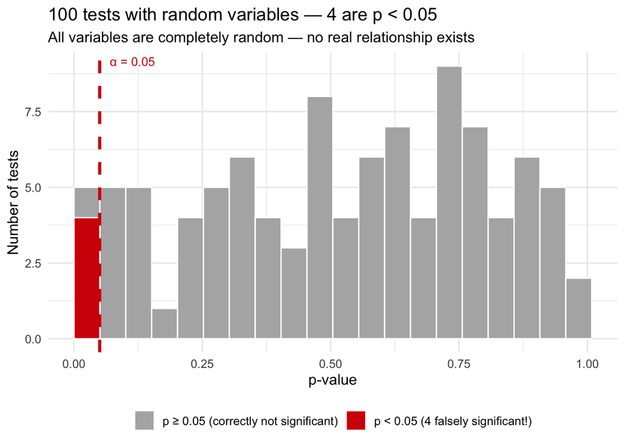

```r
tibble(
  test_nr     = 1:n_tests,
  p_value     = p_values_random,
  significant = p_values_random < 0.05
) %>%
  ggplot(aes(x = p_value, fill = significant)) +
  geom_histogram(bins = 20, color = "white", boundary = 0) +
  geom_vline(xintercept = 0.05, color = "#D50006",
             linetype = "dashed", linewidth = 1.2) +
  annotate("text", x = 0.07, y = Inf, label = "α = 0.05",
           hjust = 0, vjust = 1.5, color = "#D50006", size = 3.5) +
  scale_fill_manual(
    values = c("TRUE"  = "#D50006", "FALSE" = "#b3b2b2"),
    labels = c("TRUE"  = glue::glue("p < 0.05 ({n_significant} falsely significant!)"),
               "FALSE" = "p ≥ 0.05 (correctly not significant)")
  ) +
  labs(
    x        = "p-value",
    y        = "Number of tests",
    fill     = NULL,
    title    = glue::glue("100 tests with random variables — {n_significant} are p < 0.05"),
    subtitle = "All variables are completely random — no real relationship exists"
  ) +
  theme_minimal(base_size = 12) +
  theme(legend.position = "bottom")
```

**Note📚 Background: Why Is the p-Value Distribution Uniform?**

Under $H_0$ (no real effect), p-values are **uniformly distributed** on [0, 1]. This means: in any interval of width 0.05, about 5% of all p-values fall — including the interval [0, 0.05]. That is why α = 0.05 produces exactly 5% false positives by design.

## 4 Step 2: The Real Problem in the Bundesliga Dataset

Now we test all numeric variables in the actual dataset against `log_value` — without any content-driven hypotheses. This is data mining in its rawest form.

```r
# prepare dataset for testing
tbl_test <- tbl_buli_raw %>%
              mutate(
                log_value = log(player_market_value_euro),
                age       = lubridate::year(Sys.Date()) -
                            lubridate::year(player_dob)
              ) %>%
              select(log_value, where(is.numeric),
                     -player_market_value_euro)

# test all variables against log_value
p_values_real <- tbl_test %>%
  select(-log_value) %>%
  names() %>%
  map_dfr(function(var) {
    tryCatch({
      p <- lm(as.formula(glue::glue("log_value ~ `{var}`")),
              data = tbl_test) %>%
            broom::tidy() %>%
            filter(term != "(Intercept)") %>%
            pull(p.value)
      tibble(variable = var, p_value = p[1])
    }, error = function(e) {
      tibble(variable = var, p_value = NA_real_)
    })
  }) %>%
  filter(!is.na(p_value)) %>%
  arrange(p_value)

# top 10 — apparently significant variables
p_values_real %>%
  head(10) %>%
  gt() %>%
  fmt_number(columns = p_value, decimals = 4) %>%
  tab_style(
    style     = cell_fill(color = "#fff0f0"),
    locations = cells_body(rows = p_value < 0.05)
  ) %>%
  tab_options(table.font.size = "13px") %>%
  tab_footnote("Red = p < 0.05 without correction")
```

| variable | p_value |
| --- | --- |
| age | 0.0454 |

Red = p < 0.05 without correction

1 of 1 variables are p < 0.05 without correction. But how many are real effects versus noise?

## 5 Step 3: Benjamini-Hochberg — Controlling the FDR

Instead of controlling each individual α (**FWER**, e.g. Bonferroni), the **False Discovery Rate** controls the *proportion* of false discoveries among all discoveries:

$$\text{FDR} = \frac{\text{False Discoveries}}{\text{All Discoveries}}$$

The **Benjamini-Hochberg procedure** works as follows:

1. Sort p-values in ascending order: $p_{(1)} \leq p_{(2)} \leq \cdots \leq p_{(m)}$
2. For desired FDR level $q$: find the largest $k$ with $p_{(k)} \leq \frac{k}{m} \cdot q$
3. Declare tests $1, \ldots, k$ as significant

In R: `p.adjust(p_values, method = "BH")`

```r
p_values_adjusted <- p_values_real %>%
  mutate(
    p_bonferroni   = p.adjust(p_value, method = "bonferroni"),
    p_BH           = p.adjust(p_value, method = "BH"),
    sig_raw        = p_value      < 0.05,
    sig_bonferroni = p_bonferroni < 0.05,
    sig_BH         = p_BH         < 0.05
  )

# comparison of methods
p_values_adjusted %>%
  summarise(
    `No correction`   = sum(sig_raw,        na.rm = TRUE),
    `Bonferroni`       = sum(sig_bonferroni, na.rm = TRUE),
    `BH (FDR)`         = sum(sig_BH,         na.rm = TRUE)
  ) %>%
  pivot_longer(everything(),
               names_to  = "Method",
               values_to = "Significant") %>%
  gt() %>%
  tab_style(
    style     = cell_fill(color = "#f0fff0"),
    locations = cells_body(rows = Method == "BH (FDR)")
  ) %>%
  tab_options(table.font.size = "14px") %>%
  tab_footnote("Green = recommended method for many simultaneous tests")
```

| Method | Significant |
| --- | --- |
| No correction | 1 |
| Bonferroni | 1 |
| BH (FDR) | 1 |

Green = recommended method for many simultaneous tests

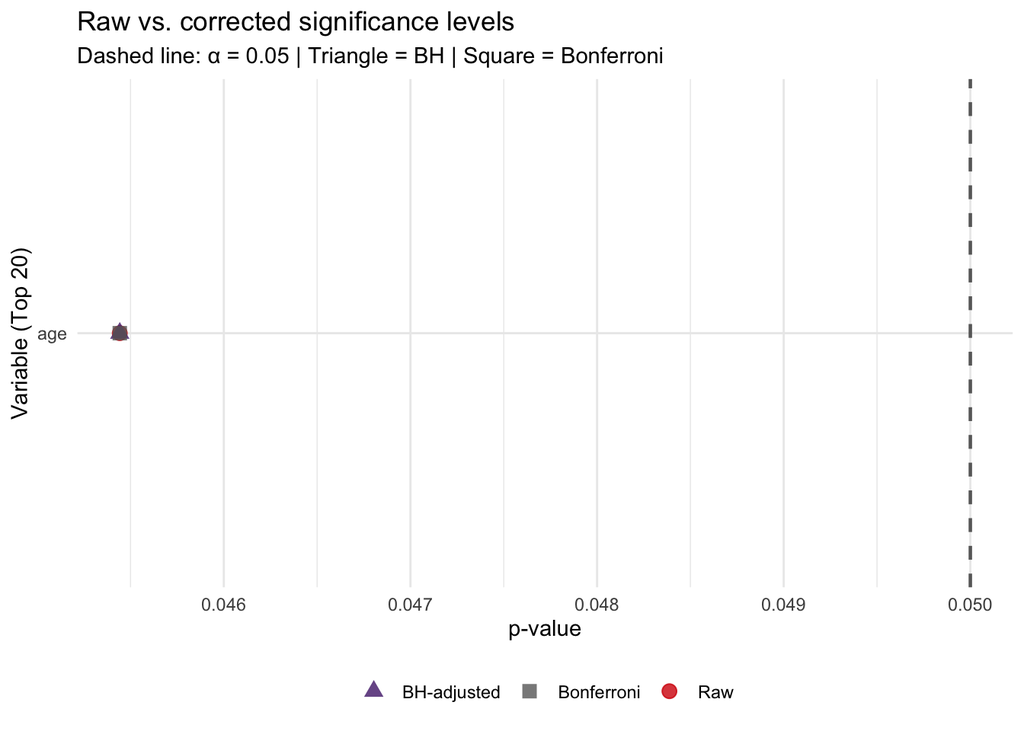

```r
p_values_adjusted %>%
  slice_head(n = 20) %>%
  mutate(variable = fct_reorder(variable, p_value)) %>%
  ggplot(aes(y = variable)) +
  geom_point(aes(x = p_value,      color = "Raw"),
             size = 3, alpha = 0.8) +
  geom_point(aes(x = p_BH,         color = "BH-adjusted"),
             size = 3, alpha = 0.8, shape = 17) +
  geom_point(aes(x = p_bonferroni, color = "Bonferroni"),
             size = 3, alpha = 0.8, shape = 15) +
  geom_vline(xintercept = 0.05, linetype = "dashed",
             color = "#686868", linewidth = 0.8) +
  scale_color_manual(
    values = c("Raw"         = "#D50006",
               "BH-adjusted" = "#502479",
               "Bonferroni"  = "#686868")
  ) +
  labs(
    x        = "p-value",
    y        = "Variable (Top 20)",
    color    = NULL,
    title    = "Raw vs. corrected significance levels",
    subtitle = "Dashed line: α = 0.05 | Triangle = BH | Square = Bonferroni"
  ) +
  theme_minimal(base_size = 11) +
  theme(legend.position = "bottom")
```

**NoteWhen to Use Which Method?**

| Situation | Method | Rationale |
| --- | --- | --- |
| 1 test, clear hypothesis | α = 0.05 classical | No multiplicity problem |
| Few tests (5–20) | **Bonferroni** | Conservative, controls FWER |
| Many tests (>50) | **BH (FDR)** | Less conservative, more power |
| Data mining, exploratory | **BH (FDR)** | Standard in data science |

## 6 Mandatory Tasks

**Important⚠️ A1: Scaling the Simulation**

Run the simulation with `n_tests = 1000`.

1. How many of 1,000 random tests are significant?
2. Does this match the theoretical expectation ($1000 \times 0.05 = 50$)?
3. What would happen if a researcher ran these 1,000 tests and published only the significant ones?

**Important⚠️ A2: Bonferroni vs. BH**

Interpret the comparison of the three methods in the table above.

**Important⚠️ A3: Break-Even Formula**

In the lecture we showed:

$$p_{\text{A}} > \frac{c(\text{FP})}{c(\text{FP}) + c(\text{FN})}$$

Suppose the FDR correction increases your confidence that a significant finding is real. How does this change your estimated $p_{\text{A}}$ for a Bundesliga transfer? Is the purchase more worthwhile with a BH-corrected result?

## 7 Bonus Tasks

**Tip💡 B1: Reproduce p-Hacking**

Simulate the classic p-hacking scenario:

```r
# researcher tests 20 variables and reports only significant ones
set.seed(1)
results <- map_dfr(1:20, function(i) {
  tbl_sim <- tbl_buli %>% mutate(x = rnorm(n()))
  p <- lm(log_value ~ x, data = tbl_sim) %>%
         broom::tidy() %>%
         filter(term == "x") %>%
         pull(p.value)
  tibble(test = i, p_value = p, significant = p < 0.05)
})
filter(results, significant)
```

How many “discoveries” get published? What would be the correct conclusion?

**Tip💡 B2: xkcd Significant**

Read: [xkcd: Significant](https://xkcd.com/882/)

Explain the joke with statistical precision — and name which p-hacking practice from this lab is depicted.

**Tip💡 B3: FDR vs. FWER**

Research the difference between **FDR** (False Discovery Rate) and **FWER** (Family-Wise Error Rate).

- In which context is FWER more important than FDR?
- Give one medical and one data-science example where the choice of method would lead to a different decision.

## 8 Summary

[output not shown]

**NoteWhat Comes Next**

Even when a finding is **truly significant** (after FDR correction) — it does not mean it is **practically relevant**. That is the topic of the next block: effect sizes and the difference between statistical and practical significance.

**Dataset used:** `buli_raw_2023-09-06.rds` (Bundesliga players, season 2022/23)